# Avetis Mishegyan Final Independent Project

## Introduction

Today we are going to present our final independent projects for Biol551 which should have:

- A new stand-alone public repository on the BIOL551 organization on GitHub
- At least 3 outputs associated with your project
  - it can be a plot, table, animation, unique useful functions, etc.
- Give a 10-minute presentation to the class explaining the data set used

The data set that I will be using is based off my research project. My project’s purpose is in the investigation of the genetic and physiological changes in flood-stressed turmeric plants as compared to control turmeric. The following data consists of the 3 physiological assays using turmeric leaf samples. These assays include soluble sugar content, chlorophyll content, and catalase activity.

## Load Libraries

Here is where we will load any libraries that we will be using. These libraries contain use full packages that are collections of R functions, data, and compiled code in a well-defined format.

```r
library(tidyverse)
library(here)
library(performance) # for checking model assumptions
library(alphonse) # for alphonse color palette
library(viridis) # for viridis color palette
```

## Load Data

Here is where we will load (ie. pull) our data as a “.csv” format into our R script. Additionally, this is where we would also inspect our data.

```r
dil_chloro_data <- read_csv(here("avetis_project", "data", "diluted_turmeric_flood_chlorophyll_test_2022_12_23.csv")) # reads in data from a .csv file
glimpse(dil_chloro_data) # allows us to inspect the data
```

```
## Rows: 36
## Columns: 5
## $ sample     <chr> "control_1", "control_1", "control_1", "control_1", "contro…
## $ leaf_id    <chr> "c1-1", "c1-1", "c1-2", "c1-2", "c1-3", "c1-3", "c2-1", "c2…
## $ treatment  <chr> "Control", "Control", "Control", "Control", "Control", "Con…
## $ abs        <chr> "abs_645", "abs_663", "abs_645", "abs_663", "abs_645", "abs…
## $ chloro_dil <dbl> 0.223, 0.682, 0.142, 0.414, 0.242, 0.712, 0.235, 0.598, 0.2…
```

```r
catalase_data <- read_csv(here("avetis_project", "data", "turmeric_flood_catalase_test_2022_12_23.csv"))
glimpse(catalase_data)
```

```
## Rows: 6
## Columns: 4
## $ sample    <chr> "control_1", "control_2", "control_3", "flood_1", "flood_2",…
## $ leaf_id   <chr> "c1", "c2", "c3", "f1", "f2", "f3"
## $ treatment <chr> "Control", "Control", "Control", "Flood", "Flood", "Flood"
## $ efferves  <dbl> 14, 8, 6, 5, 6, 7
```

```r
sugar_data <- read_csv(here("avetis_project", "data", "turmeric_flood_sugar_test_2022_12_23.csv"))
glimpse(sugar_data)
```

```
## Rows: 18
## Columns: 5
## $ sample    <chr> "control_1", "control_1", "control_1", "control_2", "control…
## $ leaf_id   <chr> "c1-1", "c1-2", "c1-3", "c2-1", "c2-2", "c2-3", "c3-1", "c3-…
## $ treatment <chr> "Control", "Control", "Control", "Control", "Control", "Cont…
## $ abs       <chr> "abs_630", "abs_630", "abs_630", "abs_630", "abs_630", "abs_…
## $ sugar     <dbl> 0.121, 0.076, 0.078, 0.141, 0.143, 0.090, 0.141, 0.133, 0.08…
```

## Data Analysis

### Chlorophyll Content Assay

#### Total Chlorophyll Function

```r
total_chlorophyll <- function(abs_645, abs_663) { # name of function, and list of inputs (ie. arguments)
  chloro_a <- 12.7*{{abs_663}} - 2.69*{{abs_645}} # code you have developed in body of the function
  chloro_b <- 22.9*{{abs_645}} - 4.68*{{abs_663}}
  total <- chloro_a + chloro_b
  return(total) # returns values we want
}

total_chlorophyll(.2, .8) # test of function
```

```
## [1] 10.458
```

#### Total Chlorophyll Calculations

```r
mean_total_calc_dil <- dil_chloro_data %>%
  pivot_wider(names_from = abs,
              values_from = chloro_dil) %>%
  mutate(total_dil = total_chlorophyll(abs_645, abs_663)*5*10) %>%
  group_by(treatment) %>%
  summarise(mean_total_dil = mean(total_dil, na.rm = TRUE),
            sd_total_dil = sd(total_dil, na.rm = TRUE))
glimpse(mean_total_calc_dil)
```

```
## Rows: 2
## Columns: 3
## $ treatment      <chr> "Control", "Flood"
## $ mean_total_dil <dbl> 424.0420, 497.8147
## $ sd_total_dil   <dbl> 92.55336, 115.07926
```

#### Bar Plot Function

```r
bar_plot <- function(data, x, y, fill, sd, lab_x, lab_y, title){
ggplot(data, aes(x = {{x}},
                 y = {{y}},
                 fill = {{fill}})) +
  geom_bar(stat = "identity") + # bar plot function
  geom_errorbar(aes(ymin = {{y}} - {{sd}}, # error bar function
                    ymax = {{y}} + {{sd}}),
                width = .2) + # adjusts width of error bars
  labs(x = lab_x,
       y = lab_y,
       title = title) +
  scale_fill_manual(values = alphonse("demon")) + # colors bars using alphonse color palette
  theme_classic() + # sets plot theme to classic
  theme(legend.position = "none") + # removes legend
  theme(plot.title = element_text(hjust = .5)) # centers plot title
}
```

#### Total Chlorophyll Bar Plot

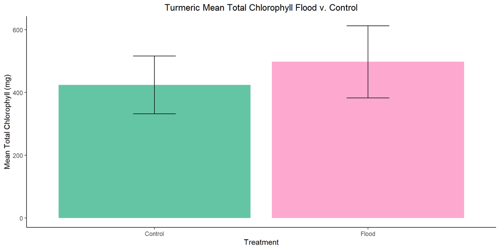

Figure 1. The mean total chlorophyll of extractions of all biological replicates consisting of 3 separate leaf samples for each biological replicate for each treatment is represented above. Biological replicates consisted of control: n = 3 and flood: n = 3. Error bars above represent standard deviation.

```r
bar_plot(data = mean_total_calc_dil,
         x = treatment,
         y = mean_total_dil,
         fill = treatment,
         sd = sd_total_dil,
         lab_x = "Treatment",
         lab_y = "Mean Total Chlorophyll (mg)",
         title = "Turmeric Mean Total Chlorophyll Flood v. Control")
```

#### Total Chlorophyll Significance Analysis

```r
raw_total_calc_dil <- dil_chloro_data %>%
  pivot_wider(names_from = abs,
              values_from = chloro_dil) %>%
  mutate(total_dil = total_chlorophyll(abs_645, abs_663)*5*10)
glimpse(raw_total_calc_dil)
```

```
## Rows: 18
## Columns: 6
## $ sample    <chr> "control_1", "control_1", "control_1", "control_2", "control…
## $ leaf_id   <chr> "c1-1", "c1-2", "c1-3", "c2-1", "c2-2", "c2-3", "c3-1", "c3-…
## $ treatment <chr> "Control", "Control", "Control", "Control", "Control", "Cont…
## $ abs_645   <dbl> 0.223, 0.142, 0.242, 0.235, 0.263, 0.195, 0.152, 0.138, 0.17…
## $ abs_663   <dbl> 0.682, 0.414, 0.712, 0.598, 0.680, 0.586, 0.465, 0.415, 0.52…
## $ total_dil <dbl> 498.8235, 309.5050, 530.0530, 477.2655, 538.4415, 432.0335, …
```

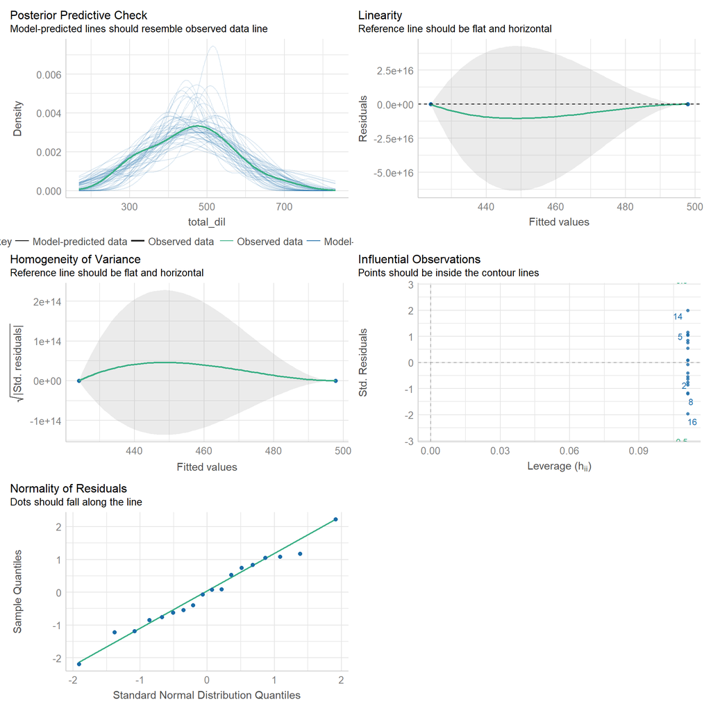

```r
total_chloro_mod <- lm(total_dil ~ treatment, data = raw_total_calc_dil) # runs a simple linear model

check_model(total_chloro_mod) # checks assumptions of an lm model
```

```r
t.test(total_dil ~ treatment, data = raw_total_calc_dil) # runs a t-test analysis
```

```
##
##  Welch Two Sample t-test
##
## data:  total_dil by treatment
## t = -1.4986, df = 15.297, p-value = 0.1543
## alternative hypothesis: true difference in means between group Control and group Flood is not equal to 0
## 95 percent confidence interval:
##  -178.51991   30.97457
## sample estimates:
## mean in group Control   mean in group Flood
##              424.0420              497.8147
```

### Sugar Content Assay

#### Sugar Content Violin and Boxplot

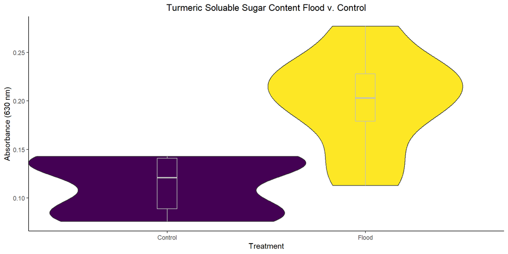

Figure 2. The median absorbance of soluble sugar of all biological replicates consisting of 3 separate leaf samples for each biological replicate for each treatment is represented above. Biological replicates consisted of control: n = 3 and flood: n = 3.

```r
sugar_data %>%
  ggplot(aes(x = treatment,
             y = sugar,
             fill = treatment)) +
  geom_violin(width = 1.4) + # violin plot function and adjusts width of box plot
  geom_boxplot(width = 0.1, # box plot function and adjusts width of box plot
               color = "grey", # sets color of box plot
               alpha = 0.2) + # sets opacity of box plot
  labs(x = "Treatment",
       y = "Absorbance (630 nm)",
       title = "Turmeric Soluable Sugar Content Flood v. Control") +
  scale_fill_viridis(discrete = TRUE) + # colors violin using viridis color palette
  theme_classic() +
  theme(legend.position = "none") +
  theme(plot.title = element_text(hjust = .5))
```

#### Sugar Significance Analysis

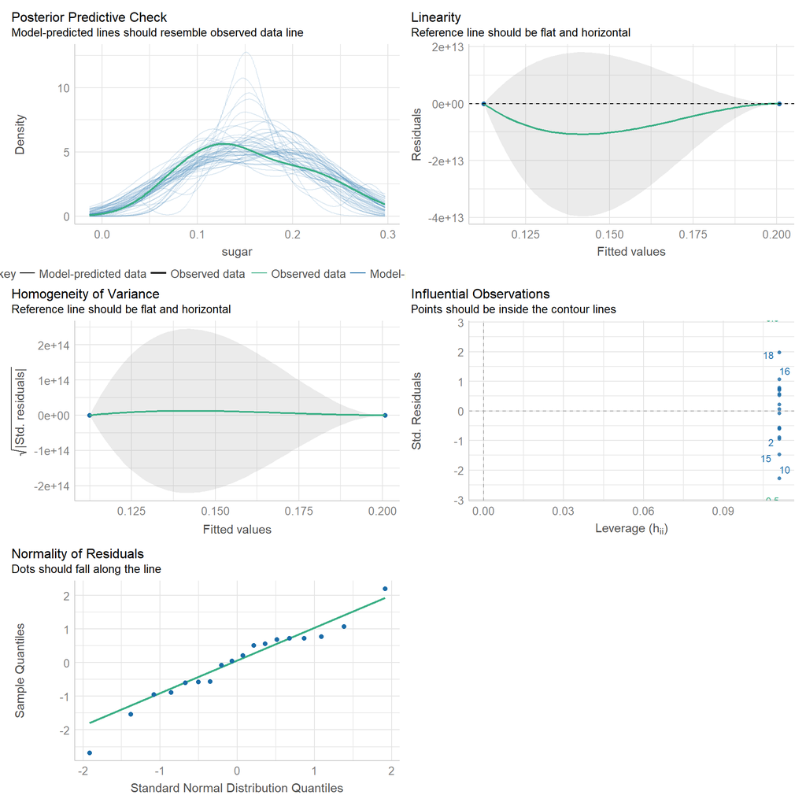

```r
sugar_data_mod <- lm(sugar ~ treatment, data = sugar_data)

check_model(sugar_data_mod)
```

```r
t.test(sugar ~ treatment, data = sugar_data)
```

```
##
##  Welch Two Sample t-test
##
## data:  sugar by treatment
## t = -4.5795, df = 12.747, p-value = 0.0005428
## alternative hypothesis: true difference in means between group Control and group Flood is not equal to 0
## 95 percent confidence interval:
##  -0.13008805 -0.04657862
## sample estimates:
## mean in group Control   mean in group Flood
##             0.1124444             0.2007778
```

### Catalase Acivity Assay

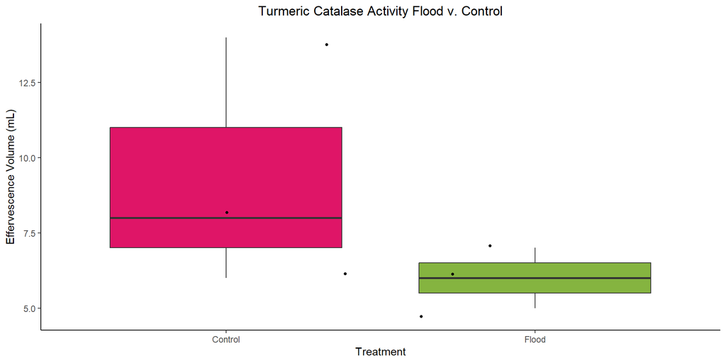

Figure 3. The median effervescence volume of all biological replicates consists of biological replicates of control: n = 3 and flood: n = 3.

```r
catalase_data %>%
  ggplot(aes(x = treatment,
             y = efferves,
             fill = treatment)) +
  geom_boxplot() +
  geom_jitter(color = "black", # jitter plot function and sets color of jitter points
              size = 1, # sets size of jitter points
              alpha = 1) + # sets opacity of jitter points
  labs(x = "Treatment",
       y = "Effervescence Volume (mL)",
       title = "Turmeric Catalase Activity Flood v. Control") +
  scale_fill_manual(values = alphonse("jojo")) + # colors bars using alphonse color palette
  theme_classic() +
  theme(legend.position = "none") +
  theme(plot.title = element_text(hjust = .5))
```

#### Catalase Significance Analysis

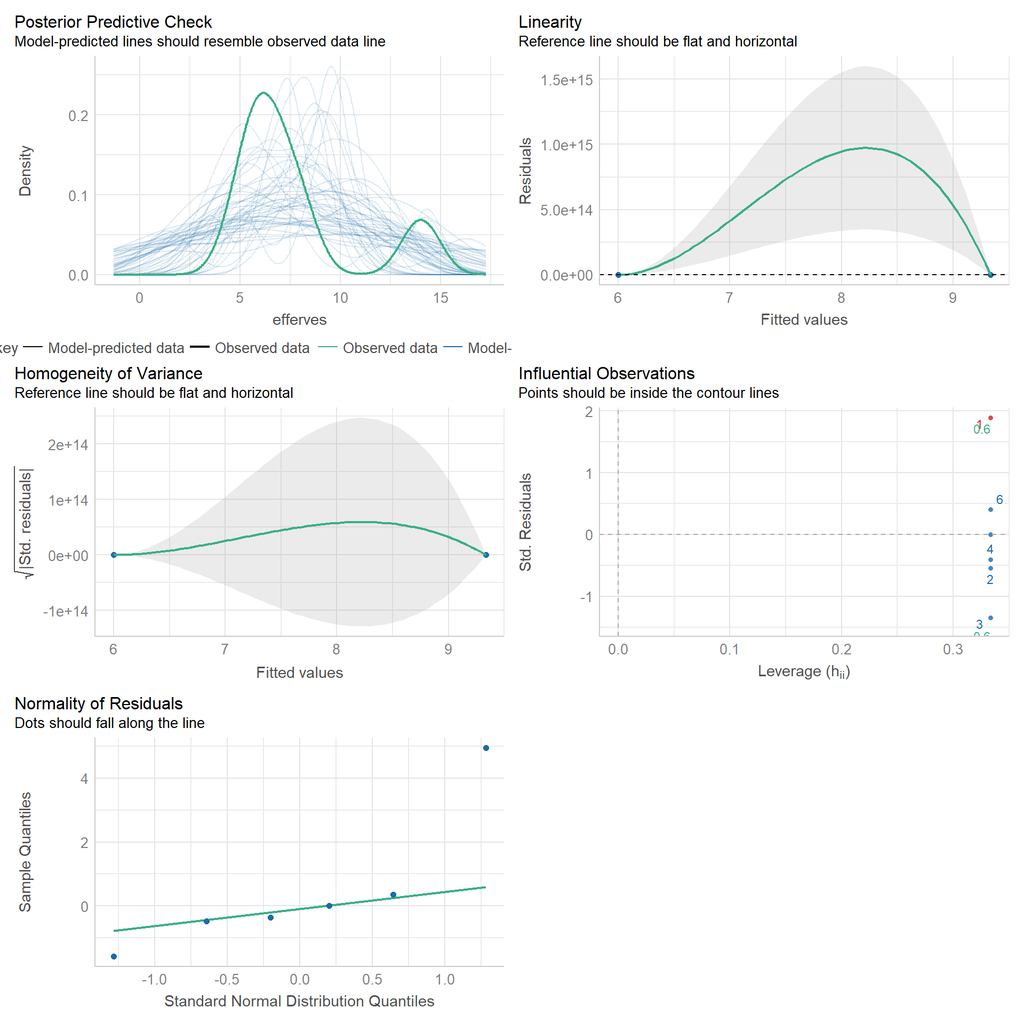

```r
catalase_data_mod <- lm(efferves ~ treatment, data = catalase_data)

check_model(catalase_data_mod)
```

```r
t.test(efferves ~ treatment, data = catalase_data)
```

```
##
##  Welch Two Sample t-test
##
## data:  efferves by treatment
## t = 1.3484, df = 2.23, p-value = 0.2981
## alternative hypothesis: true difference in means between group Control and group Flood is not equal to 0
## 95 percent confidence interval:
##  -6.317989 12.984656
## sample estimates:
## mean in group Control   mean in group Flood
##              9.333333              6.000000
```